# R Notebook

```r
library(dplyr)
library(readr)
library(stringr)
library(tibble)
library(here)
library(tidyr)
library(ggplot2)
source(here("RScripts", "Oyster_Library.R"))
library(vegan)
library(ggvegan)
```

```r
# More color-blind friendly colorbalettes
#http://colorbrewer2.org/#type=qualitative&scheme=Paired&n=10
cb10 <- c('#a6cee3','#1f78b4','#b2df8a','#33a02c','#fb9a99','#e31a1c','#fdbf6f','#ff7f00','#cab2d6','#6a3d9a')

cb12 <- c('#a6cee3','#1f78b4','#b2df8a','#33a02c','#fb9a99','#e31a1c','#fdbf6f','#ff7f00','#cab2d6','#6a3d9a','#ffff99','#b15928')

# Less color-blind friendly, but still nice.
#https://sashat.me/2017/01/11/list-of-20-simple-distinct-colors/
trub20 <- c('#e6194b','#3cb44b','#ffe119','#0082c8','#f58231','#911eb4','#46f0f0','#f032e6','#d2f53c','#fabebe','#008080','#e6beff','#aa6e28','#fffac8','#800000','#aaffc3','#808000','#ffd8b1','#000080','#808080','#FFFFFF','#000000')
```

```r
dataDir <- "Hatchery_UVexperiment_All"
metadata <- read_csv(here(dataDir, paste0("metadata_expanded.csv")))
counts <- read_csv(here(dataDir, paste0("counts_", dataDir, ".csv"))) %>%
  rename(ASV = 1)
tax <- read_csv(here(dataDir, paste0("tax_", dataDir, ".csv"))) %>% add_tag_to_tax()
```

Save out abridged metadata so I can add dates to broods

```r
data_for_steff_0 <- metadata %>% select(`Brood#`, Date, DayN, Info2) %>%
  filter(Info2 %in% c("Best", "Ok", "Poor", "NoSurvivors")) %>%
  mutate(Date = as.Date(as.numeric(Date), origin = "1899-12-30")) %>%# Excel origin https://stackoverflow.com/questions/43230470/how-to-convert-excel-date-format-to-proper-date-in-r
  arrange(`Brood#`)

data_for_steff <- data_for_steff_0 %>%
    group_by(`Brood#`) %>%
  arrange(DayN) %>%
  summarise(across(c(Date, DayN, Info2), first))
data_for_steff
```

| Brood# | Date | DayN | Info2 |
| --- | --- | --- | --- |
| 21-10 | 2021-04-22 | 3 | Best |
| 21-11 | 2021-04-26 | 5 | NoSurvivors |
| 21-23 | 2021-05-20 | 3 | Ok |
| 21-38 | 2021-06-21 | 4 | Best |
| 21-43 | 2021-06-29 | 4 | Best |
| 21-56 | 2021-07-27 | 4 | Ok |
| 21-57 | 2021-07-29 | 3 | Poor |
| 21-58 | 2021-08-02 | 5 | Poor |
| 21-63 | 2021-08-16 | 3 | NoSurvivors |
| 21-68 | 2021-08-30 | 4 | NoSurvivors |

[output cut: 1 more lines]

```r
write_csv(data_for_steff, here("IntermediateData", "BroodInfoCram2021.csv"))
write_csv(data_for_steff_0, here("IntermediateData", "BroodInfoCram2021_all.csv"))
```

```r
data_for_steff_0 %>% filter(`Brood#` == "21-58")
```

[output not shown]

Keep only the main hatchery data

```r
nonOyster <- fortify_oyster(counts, tax)
```

```r
metadata_main <- metadata %>%
  filter(Info1 %in% c("Good", "Crash"))
```

```r
nonOysterM <- nonOyster %>%
  filter(Sample0 %in% unique(metadata_main$Sample0))
```

```r
BactAbun <- nonOysterM %>%
  group_by(Sample0) %>%
  summarise(ratio = sum(ratio)) %>%
  left_join(metadata_main, by = "Sample0")
```

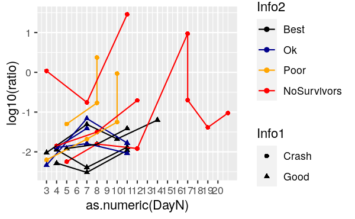

```r
BactAbun %>%
  filter(!Info2 %in% c("Charcoal", "Unknown")) %>%
  mutate(Info2 = forcats::fct_relevel(Info2, c("Best", "Ok", "Poor", "NoSurvivors"))) %>%
  ggplot(aes(x = as.numeric(DayN), y = log10(ratio), shape = Info1, color = Info2, group = `Brood#`)) + geom_point() + scale_color_manual(values = c("black", "darkblue", "orange", "red")) + geom_path() +
  scale_x_continuous(breaks = c(1:20))
```

Can we keep taxa things that show up at least n times only?

```r
nSamples <- nonOysterM$Sample0 %>% unique() %>% length()

hitFracDf <- nonOysterM %>%
  select(ASV, count, ratio) %>%
  mutate(enoughHits = count>=3) %>%
  group_by(ASV) %>%
  summarise(hits = sum(enoughHits)) %>%
  mutate(hitfrac = hits/nSamples) %>%
  identity()

hitFracOk <- hitFracDf %>%
  filter(hitfrac > 0.2)

nonOyster20 <- nonOysterM %>%
  filter(ASV %in% hitFracOk$ASV)
```

```r
ratioDf <- nonOyster20 %>%
  select(Sample0, ASV, ratio) %>%
  pivot_wider(names_from = ASV, values_from = ratio, values_fill = 0) %>%
  column_to_rownames("Sample0") %>%
  identity()
```

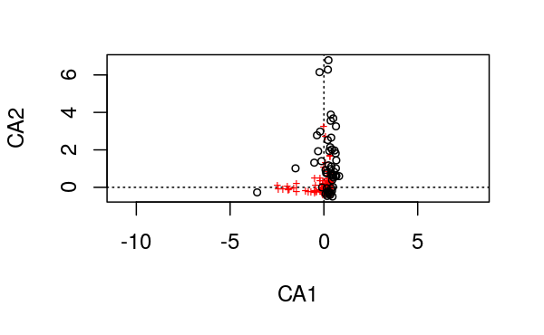

```r
my_ca <- cca(sqrt(ratioDf))
plot(my_ca)
```

```r
ca_scores <- fortify(my_ca, display = "wa", axes = 1:6) %>%
  rename(Sample0 = Label)
```

```r
caDf <- BactAbun %>%
  left_join(ca_scores, by = "Sample0")
```

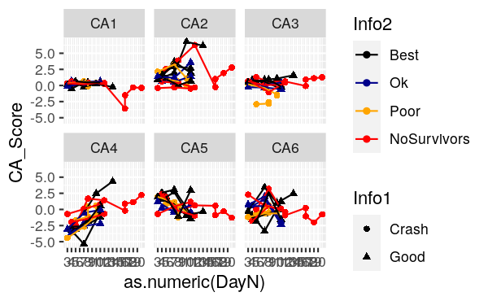

```r
caDf %>%
  filter(!Info2 %in% c("Charcoal", "Unknown")) %>%
  mutate(Info2 = forcats::fct_relevel(Info2, c("Best", "Ok", "Poor", "NoSurvivors"))) %>%
  select(DayN, Info1, Info2, starts_with("CA"), `Brood#`) %>%
  pivot_longer(cols = starts_with("CA"), names_to = "CA_Axis", values_to = "CA_Score") %>%
  ggplot(aes(x = as.numeric(DayN), y = CA_Score, shape = Info1, color = Info2, group = `Brood#`)) + geom_point() + scale_color_manual(values = c("black", "darkblue", "orange", "red")) + geom_path() +
  scale_x_continuous(breaks = c(1:20)) +
  facet_wrap(~CA_Axis)
```

No particularly clear pattern at this point.

Lets do a cca with respect to day and Crash vs Not. %>% mutate(Info1 = as.factor(Info1)

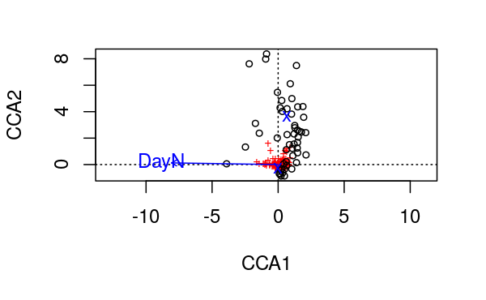

```r
first_cca <- cca(sqrt(ratioDf) ~ DayN + Info1, data = metadata_main )

plot(first_cca)
```

```r
anova(first_cca, by = "margin")
```

```
Permutation test for cca under reduced model
Marginal effects of terms
Permutation: free
Number of permutations: 999

Model: cca(formula = sqrt(ratioDf) ~ DayN + Info1, data = metadata_main)
         Df ChiSquare      F Pr(>F)
DayN      1   0.18429 5.9236  0.001 ***
Info1     1   0.09205 2.9587  0.001 ***
Residual 48   1.49333
---
Signif. codes:  0 ‘***’ 0.001 ‘**’ 0.01 ‘*’ 0.05 ‘.’ 0.1 ‘ ’ 1
```

```r
cca_scores <- fortify(first_cca, display = "wa") %>% rename(Sample0 = Label)
cca_scores
```

| Score | Sample0 | CCA1 | CCA2 | CA1 | CA2 | CA3 | CA4 |
| --- | --- | --- | --- | --- | --- | --- | --- |
| sites | H138 | 0.32166132 | 4.01615653 | -1.79409499 | -0.8371556550 | -0.13443257 | -2.35536597 |
| sites | H141 | 0.92038025 | 6.11111773 | 0.07630491 | 0.9624141105 | 1.83443143 | -3.90985315 |
| sites | H144 | 1.01526630 | 3.81761492 | 0.54809317 | 0.0788299894 | -0.49307036 | 0.99936068 |
| sites | H148 | 1.93440444 | 3.57671014 | -0.73554299 | -0.5171907798 | 1.07162814 | -2.06213622 |
| sites | H152 | 1.38672710 | 7.49001299 | -1.52576749 | -0.1728499985 | 0.93370359 | -3.17814248 |
| sites | H158 | 0.15079846 | 4.29051314 | 0.73889060 | 1.1161521771 | -0.44955513 | 1.60860587 |
| sites | H187 | 1.20731277 | 2.31435388 | -0.49988120 | -1.0013546344 | -1.19157531 | 0.61405502 |
| sites | H192 | 2.08793985 | 2.41579520 | -0.93334444 | -1.3899098893 | -0.35813708 | -0.25850529 |
| sites | H195 | 1.87695112 | 4.38738178 | -1.37082308 | 1.1907008696 | 2.55312575 | -3.33983087 |
| sites | H196 | 1.51673086 | 2.08355766 | -0.48299425 | -1.1806945987 | -1.13982330 | 0.53496888 |

[output cut: 41 more lines]

```r
ccaDf <- BactAbun %>%
  left_join(cca_scores, by = "Sample0")
```

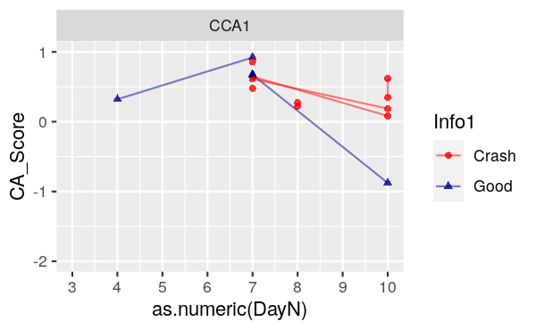

```r
ccaDf %>%
  #filter(!Info2 %in% c("Charcoal", "Unknown")) %>%
  #mutate(Info2 = forcats::fct_relevel(Info2, c("Best", "Ok", "Poor", "NoSurvivors"))) %>%
  select(DayN, Info1, Info2, starts_with("CCA1"), `Brood#`) %>%
  pivot_longer(cols = starts_with("CCA"), names_to = "CA_Axis", values_to = "CA_Score") %>%
  ggplot(aes(x = as.numeric(DayN), y = CA_Score, shape = Info1, color = Info1, group = `Brood#`)) + geom_point(alpha = 0.8) +
  scale_color_manual(values = c(Crash = "red", Good = "darkblue")) + geom_path(alpha = 0.5) +
  scale_x_continuous(breaks = c(1:20), limits = c(3, 10)) +
  scale_y_continuous(limits = c(-2, 1)) +
  facet_wrap(~CA_Axis)
```

# Early bird microbes

Hmm everyone is first measured on days 3, 4 or 5. What if we just compare those microbiota?

```r
metadata_early <- metadata_main %>%
  filter(DayN <=5)
```

```r
ratioDf_early <- ratioDf[rownames(ratioDf) %in% metadata_early$Sample, ]
```

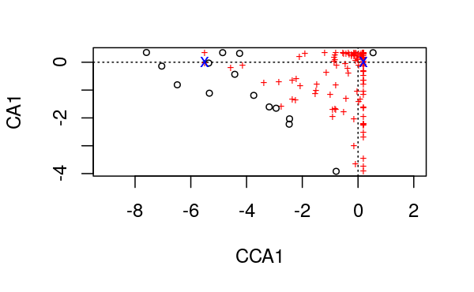

```r
early_cca <- cca((ratioDf_early) ~ Info1, data = metadata_early)
plot(early_cca)
```

```r
anova(early_cca, permutations = how(nperm = 9999))
```

```
Permutation test for cca under reduced model
Permutation: free
Number of permutations: 9999

Model: cca(formula = (ratioDf_early) ~ Info1, data = metadata_early)
         Df ChiSquare      F Pr(>F)
Model     1   0.17425 0.9925 0.6074
Residual 13   2.28234
```

```r
early_scores <- fortify(early_cca, display = "wa") %>% rename(Sample0 = Label)
early_cn0 <- fortify(early_cca, display = "cn")
earlyDf <- metadata_early %>% left_join(early_scores, by = "Sample0") %>%
  left_join(BactAbun %>% select(Sample0, ratio), by = "Sample0")
```

# Can I add mean (and sd of abundance to the centroids)

```r
ecn_meta <- metadata_early %>%
  left_join(BactAbun %>% select(Sample0, ratio), by = "Sample0") %>%
  group_by(Info1) %>%
  summarise(mean_ratio = mean(na.omit(ratio)), sd_ratio = sd(na.omit(ratio)),
            median_ratio = median(ratio), mad_ratio = mad(ratio),
            n_ratio = n(), se_ratio = mean_ratio/sqrt(n_ratio))

early_cn <- early_cn0 %>%
  mutate(Info1 = str_remove(Label, "Info1")) %>%
  left_join(ecn_meta, by = "Info1")
```

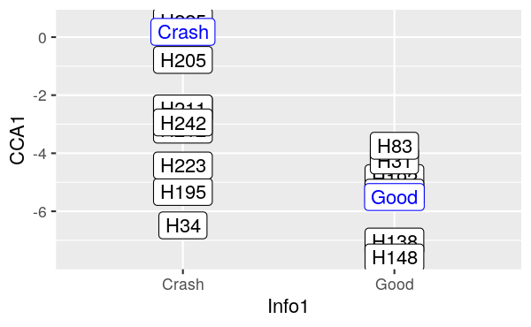

```r
earlyDf %>%
  ggplot(aes(x = Info1, y = CCA1)) + geom_point() + geom_label(aes(label = Sample0)) + geom_label(aes(x = Info1, label = Info1), color = "blue", data = early_cn %>% mutate(Info1 = str_remove(Label, "Info1")))
```

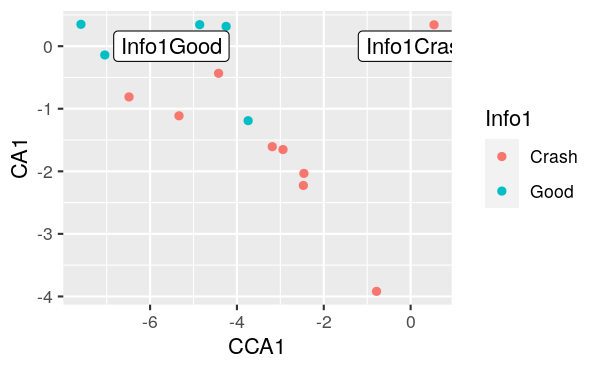

```r
earlyDf %>%
  ggplot(aes(x = CCA1, y = CA1, col = Info1)) + geom_point() +
  geom_label(aes(label = Label), col = "black", data = early_cn)
```

```r
  scale_color_manual(values = c(Crash = "red", Good = "black"))
```

[output not shown]

This seems unlikely to be real. Or if it is real, there are a lot of exceptions to the pattern.

```r
early_rda <- rda(log10(ratioDf_early + 1/1000) ~ Info1, data = metadata_early)
#plot(early_rda)
anova(early_rda, permutations = how(nperm = 9999))
```

```
Permutation test for rda under reduced model
Permutation: free
Number of permutations: 9999

Model: rda(formula = log10(ratioDf_early + 1/1000) ~ Info1, data = metadata_early)
         Df Variance      F Pr(>F)
Model     1   0.1583 0.7863 0.5473
Residual 13   2.6174
```

# Species of interest

I’d like mean abundance for each taxon

```r
ASV_early_mean_ratio <- nonOyster20 %>%
  inner_join(metadata_early, by = "Sample0") %>%
  group_by(ASV) %>%
  summarise(ratio = mean(ratio))

ASV_early_mean_ratio_2 <- nonOyster20 %>%
  inner_join(metadata_early, by = "Sample0") %>%
  group_by(ASV, Info1) %>%
  summarise(ratio = mean(ratio), sd = sd(na.omit((ratio)))) %>%
  #pivot_wider(names_from = Info1, values_from = ratio, values_fill = 0) %>%
  identity()
ASV_early_mean_ratio_2
```

| ASV | Info1 | ratio | sd |
| --- | --- | --- | --- |
| ASV_10 | Crash | 1.437407e-04 | NA |
| ASV_10 | Good | 0.000000e+00 | NA |
| ASV_102 | Crash | 1.805367e-04 | NA |
| ASV_102 | Good | 0.000000e+00 | NA |
| ASV_103 | Crash | 3.315980e-05 | NA |
| ASV_103 | Good | 0.000000e+00 | NA |
| ASV_106 | Crash | 0.000000e+00 | NA |
| ASV_106 | Good | 5.561735e-06 | NA |
| ASV_11 | Crash | 1.356438e-02 | NA |
| ASV_11 | Good | 2.885438e-04 | NA |

[output cut: 256 more lines]

```r
nonOyster20 %>%
  inner_join(metadata_early, by = "Sample0") %>%
  filter(ASV == "ASV_10") %>%
  summarise()
```

```r
# I shouldn't have removed the zeros.
```

```r
early_sp <- fortify(early_cca, display = "sp") %>%
  rename(ASV = Label) %>%
  left_join(tax, by = "ASV") %>%
  left_join(ASV_early_mean_ratio, by = "ASV")
```

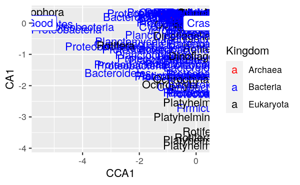

```r
early_sp %>%
  ggplot(aes(x = CCA1, y = CA1, label = Phylum, color = Kingdom)) + geom_text() + scale_color_manual(values = c("red", "blue", "black")) +
  geom_label(aes(x = CCA1, y = 0, label = Info1), color = "blue", data = early_cn %>% mutate(Info1 = str_remove(Label, "Info1")))
```

```r
headtail <- function(df, n = 10){bind_rows(head(df, n), tail(df, n))}
early_sp_best <- early_sp %>% arrange(CCA1) %>% headtail(n = 5)
```

```r
library(ggrepel)
```

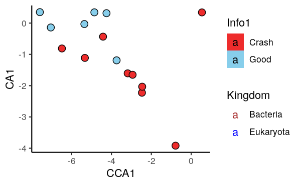

```r
  ggplot() +
  geom_point(aes(x = CCA1, y = CA1, fill = Info1), data = earlyDf, shape = 21, size = 3) +
  scale_fill_manual(values = c(Crash = "firebrick2", Good = "skyblue")) +
  geom_text_repel(aes(x = CCA1, y = CA1, label = Tag_ASV, color = Kingdom), data = early_sp_best, inherit.aes = FALSE) +
  scale_color_manual(values = c(Bacteria = "brown", Eukaryota = "blue")) +
  geom_label_repel(aes(x = CCA1, y = 0, label = Info1, fill = Info1), color = "black", data = early_cn %>% mutate(Info1 = str_remove(Label, "Info1")), inherit.aes = FALSE) +
  theme_classic()
```

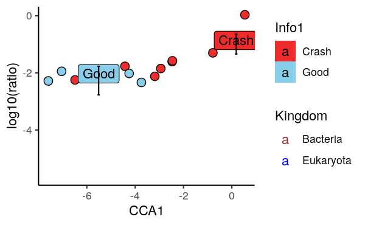

```r
ggplot(aes(x = CCA1, y = log10(ratio)), data = earlyDf) +
  geom_point(aes(fill = Info1), data = earlyDf, shape = 21, size = 3) + # Samples
  scale_fill_manual(values = c(Crash = "firebrick2", Good = "skyblue")) +
  geom_text_repel(aes(label = Tag_ASV, color = Kingdom), data = early_sp_best, inherit.aes = TRUE) + # taxa
  scale_color_manual(values = c(Bacteria = "brown", Eukaryota = "blue")) +
  geom_label(aes(x = CCA1, y = log10(mean_ratio), label = Info1, fill = Info1), color = "black", data = early_cn , inherit.aes = FALSE) + # centroids
  #geom_errorbar(aes(x = CCA1, ymin = log10(mean_ratio - se_ratio), ymax = log10(mean_ratio + se_ratio)), data = early_cn) +
  geom_errorbar(aes(x = CCA1, ymin = log10(mean_ratio - 2 * se_ratio), ymax = log10(mean_ratio + 2 * se_ratio)), width = 0.1, data = early_cn, inherit.aes = FALSE) +
  #geom_errorbar(aes(x = CCA1, ymin = log10(median_ratio - mad_ratio), ymax = log10(median_ratio + mad_ratio)), width = 0.1, data = early_cn, inherit.aes = FALSE) +
  theme_classic()
ggsave(here("Figures", "CCAAbun.png"))
```

Ok, what I’d like to do next is explore what the archtypical “good vs crashed” community might look like.

O, this appears to be non trivial. what if I instead look at the community structure, crashed and not, first three days, as stacked bars, or points

```r
no2e <- nonOyster20 %>%
  inner_join(metadata_main, by = "Sample0") %>%
  filter(DayN <=5)
```

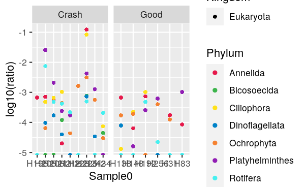

```r
no2e %>% group_by(Sample0, Phylum) %>%
  summarize(across(c(Info1, `Brood#`, Kingdom), first), ratio = sum(ratio)) %>%
  filter(Kingdom == "Eukaryota") %>%
  ggplot(aes(x = Sample0, y = log10(ratio), color = Phylum, shape = Kingdom)) + geom_point() + facet_wrap(~`Info1`, scales = "free_x") + scale_color_manual(values = rep(trub20, 2))
```

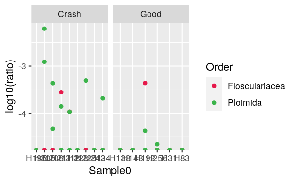

```r
no2e %>% group_by(Sample0, ASV) %>%
  summarize(across(c(Info1, `Brood#`, Phylum, Order), first), ratio = sum(ratio)) %>%
  filter(Phylum == "Rotifera") %>%
  ggplot(aes(x = Sample0, y = log10(ratio), color = Order)) + geom_point() + facet_wrap(~`Info1`, scales = "free_x") + scale_color_manual(values = rep(trub20, 2))
```

Order olycladida

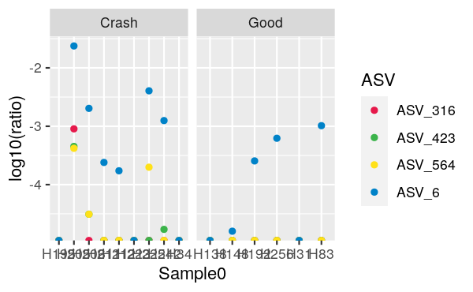

```r
no2e %>% group_by(Sample0, ASV) %>%
  summarize(across(c(Info1, `Brood#`, Phylum:Genus), first), ratio = sum(ratio)) %>%
  filter(Phylum == "Platyhelminthes") %>%
  ggplot(aes(x = Sample0, y = log10(ratio), color = ASV)) + geom_point() + facet_wrap(~`Info1`, scales = "free_x") + scale_color_manual(values = rep(trub20, 2))
```

Flatworms are a thing apparently

## What about actuall machine learning. Start with glmnet?

```r
library(glmnet)
```

```r
?glmnet
```

```r
comX <- log10(ratioDf_early + 1/1000)
resY <- metadata_early$Info1
```

```r
mod01 <- glmnet(x = comX, y = resY, family = "binomial")
```

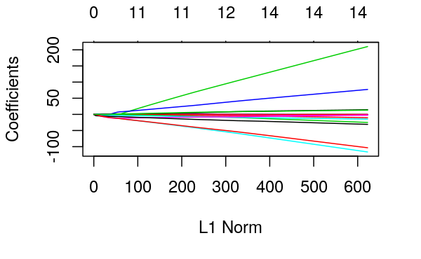

```r
plot(mod01)
```

```r
print(mod01)
```

```
Call:  glmnet(x = comX, y = resY, family = "binomial")

    Df  %Dev   Lambda
1    0  0.00 0.244400
2    1  1.65 0.233300
3    1  3.19 0.222700
4    1  4.61 0.212500
5    1  5.95 0.202900
6    1  7.19 0.193700
7    3  8.64 0.184900
8    4 10.79 0.176500
9    4 12.88 0.168400
10   4 14.83 0.160800
11   5 16.78 0.153500
12   5 18.99 0.146500
```

[output cut: 88 more lines]

```r
coef(mod01,  s = 0.2)
```

```
134 x 1 sparse Matrix of class "dgCMatrix"
                   s1
(Intercept) -9.375833
ASV_4        .
ASV_5        .
ASV_6        .
ASV_7        .
ASV_9        .
ASV_10       .
ASV_11       .
ASV_13       .
ASV_14       .
ASV_15       .
ASV_16       .
ASV_19       .
ASV_20       .
ASV_23       .
ASV_25       .
ASV_28       .
ASV_30       .
ASV_33       .
ASV_35       .
ASV_37       .
ASV_38       .
ASV_39       .
ASV_40       .
ASV_41       .
ASV_42       .
ASV_44       .
ASV_46       .
ASV_47       .
ASV_50       .
ASV_52       .
ASV_53       .
ASV_54       .
ASV_55       .
ASV_57       .
ASV_58       .
ASV_59       .
ASV_60       .
```

[output cut: 81 more lines]

```
ASV_436      .
ASV_452      .
ASV_474      .
ASV_501      .
ASV_538      .
ASV_555      .
ASV_564      .
ASV_565      .
ASV_573      .
ASV_589      .
ASV_603      .
ASV_679      .
ASV_725      .
ASV_758      .
ASV_905      .
```

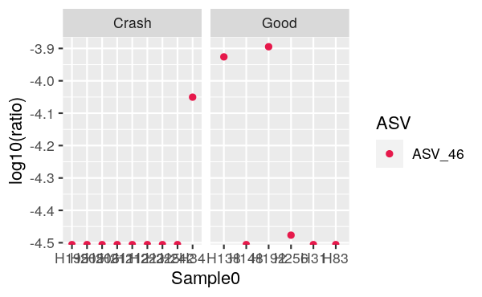

```r
no2e %>% group_by(Sample0, ASV) %>%
  summarize(across(c(Info1, `Brood#`, Phylum:Genus), first), ratio = sum(ratio)) %>%
  filter(ASV == "ASV_46") %>%
  ggplot(aes(x = Sample0, y = log10(ratio), color = ASV)) + geom_point() + facet_wrap(~`Info1`, scales = "free_x") + scale_color_manual(values = rep(trub20, 2))
```

Hah.

```r
mod01cv <- cv.glmnet(x = as.matrix(comX), y = resY, family = "binomial")
```

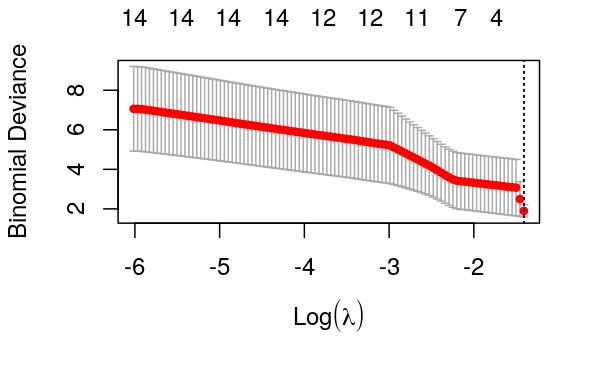

```r
plot(mod01cv)
```

```r
mod01cv$lambda.min
```

```
[1] 0.2443726
```

```r
mod01cv$lambda.1se
```

```
[1] 0.2443726
```

```r
coef(mod01cv, s = "lambda.min")
```

```
134 x 1 sparse Matrix of class "dgCMatrix"
                    s1
(Intercept) -0.4054651
ASV_4        .
ASV_5        .
ASV_6        .
ASV_7        .
ASV_9        .
ASV_10       .
ASV_11       .
ASV_13       .
ASV_14       .
ASV_15       .
ASV_16       .
ASV_19       .
ASV_20       .
ASV_23       .
ASV_25       .
ASV_28       .
ASV_30       .
ASV_33       .
ASV_35       .
ASV_37       .
ASV_38       .
ASV_39       .
ASV_40       .
ASV_41       .
ASV_42       .
ASV_44       .
ASV_46       .
ASV_47       .
ASV_50       .
ASV_52       .
ASV_53       .
ASV_54       .
ASV_55       .
ASV_57       .
ASV_58       .
ASV_59       .
ASV_60       .
```

[output cut: 81 more lines]

```
ASV_436      .
ASV_452      .
ASV_474      .
ASV_501      .
ASV_538      .
ASV_555      .
ASV_564      .
ASV_565      .
ASV_573      .
ASV_589      .
ASV_603      .
ASV_679      .
ASV_725      .
ASV_758      .
ASV_905      .
```

Well, I guess not that approach. Prediction isn’t going to be our thing. The best model just uses the intercept.

## Distance stats

```r
logRatioMtx_early <- log10(as.matrix(ratioDf_early + 1/1000))
metadata_early_match <- tibble(Sample0 = rownames(logRatioMtx_early)) %>%
  left_join(metadata_early, by = "Sample0")

eucDist_early <- as.matrix(dist(logRatioMtx_early))
```

```r
anosim(eucDist_early, metadata_early_match$Info1)
```

```
Call:
anosim(x = eucDist_early, grouping = metadata_early_match$Info1)
Dissimilarity: user supplied square matrix

ANOSIM statistic R: -0.07625
      Significance: 0.787

Permutation: free
Number of permutations: 999
```

So not with the euclidian distance, as I expected but what about chisquare

```r
chiDist_early <- ExPosition::chi2Dist(logRatioMtx_early)$D
anosim(chiDist_early, metadata_early_match$Info1)
```

```
Call:
anosim(x = chiDist_early, grouping = metadata_early_match$Info1)
Dissimilarity: user supplied square matrix

ANOSIM statistic R: -0.08569
      Significance: 0.813

Permutation: free
Number of permutations: 999
```

Also no. How strange. I wonder how this even works.

# Stuff I want to know.

- Whats up with the sampling schedule eg day 3,4,5
- How many survivors at each time point?

# Stuff I might do

Logistic (or OLS or poisson if i get survivor numbers) regression of each taxon (each level) vs crashyness.

Plot abundance of CCA taxa during and not during crashes (with standard errors). Fewer of them than I’m plotting now.